# Risk Factor Analysis

## Outcome Variable

**Outcome Variable:** pers_wast

## Predictor Variables

**Intervention Variable:** mhtcm

**Adjustment Set:**

- arm
- W_mage
- meducyrs
- feducyrs
- single
- delta_W_mage
- delta_meducyrs
- delta_feducyrs
- delta_single

## Stratifying Variables

The analysis was stratified on these variable(s):

- agecat
- studyid
- country

## Data Summary

| agecat | studyid | country | mhtcm | pers_wast | n_cell | n |
| --- | --- | --- | --- | --- | --- | --- |
| 0-24 months | ki0047075b-MAL-ED | BANGLADESH | >=155 cm | 0 | 21 | 248 |
| 0-24 months | ki0047075b-MAL-ED | BANGLADESH | >=155 cm | 1 | 3 | 248 |
| 0-24 months | ki0047075b-MAL-ED | BANGLADESH | <151 cm | 0 | 154 | 248 |
| 0-24 months | ki0047075b-MAL-ED | BANGLADESH | <151 cm | 1 | 7 | 248 |
| 0-24 months | ki0047075b-MAL-ED | BANGLADESH | [151-155) cm | 0 | 60 | 248 |
| 0-24 months | ki0047075b-MAL-ED | BANGLADESH | [151-155) cm | 1 | 3 | 248 |
| 0-24 months | ki0047075b-MAL-ED | BRAZIL | >=155 cm | 0 | 124 | 217 |
| 0-24 months | ki0047075b-MAL-ED | BRAZIL | >=155 cm | 1 | 2 | 217 |
| 0-24 months | ki0047075b-MAL-ED | BRAZIL | <151 cm | 0 | 52 | 217 |
| 0-24 months | ki0047075b-MAL-ED | BRAZIL | <151 cm | 1 | 0 | 217 |
| 0-24 months | ki0047075b-MAL-ED | BRAZIL | [151-155) cm | 0 | 39 | 217 |
| 0-24 months | ki0047075b-MAL-ED | BRAZIL | [151-155) cm | 1 | 0 | 217 |
| 0-24 months | ki0047075b-MAL-ED | INDIA | >=155 cm | 0 | 53 | 240 |
| 0-24 months | ki0047075b-MAL-ED | INDIA | >=155 cm | 1 | 2 | 240 |
| 0-24 months | ki0047075b-MAL-ED | INDIA | <151 cm | 0 | 102 | 240 |
| 0-24 months | ki0047075b-MAL-ED | INDIA | <151 cm | 1 | 13 | 240 |
| 0-24 months | ki0047075b-MAL-ED | INDIA | [151-155) cm | 0 | 64 | 240 |
| 0-24 months | ki0047075b-MAL-ED | INDIA | [151-155) cm | 1 | 6 | 240 |
| 0-24 months | ki0047075b-MAL-ED | NEPAL | >=155 cm | 0 | 41 | 238 |
| 0-24 months | ki0047075b-MAL-ED | NEPAL | >=155 cm | 1 | 0 | 238 |
| 0-24 months | ki0047075b-MAL-ED | NEPAL | <151 cm | 0 | 131 | 238 |
| 0-24 months | ki0047075b-MAL-ED | NEPAL | <151 cm | 1 | 2 | 238 |
| 0-24 months | ki0047075b-MAL-ED | NEPAL | [151-155) cm | 0 | 62 | 238 |
| 0-24 months | ki0047075b-MAL-ED | NEPAL | [151-155) cm | 1 | 2 | 238 |
| 0-24 months | ki0047075b-MAL-ED | PERU | >=155 cm | 0 | 58 | 283 |
| 0-24 months | ki0047075b-MAL-ED | PERU | >=155 cm | 1 | 0 | 283 |
| 0-24 months | ki0047075b-MAL-ED | PERU | <151 cm | 0 | 165 | 283 |
| 0-24 months | ki0047075b-MAL-ED | PERU | <151 cm | 1 | 0 | 283 |
| 0-24 months | ki0047075b-MAL-ED | PERU | [151-155) cm | 0 | 59 | 283 |
| 0-24 months | ki0047075b-MAL-ED | PERU | [151-155) cm | 1 | 1 | 283 |

[output cut: 342 more lines]

The following strata were considered:

- agecat: 0-24 months, studyid: ki0047075b-MAL-ED, country: BANGLADESH
- agecat: 0-24 months, studyid: ki0047075b-MAL-ED, country: BRAZIL
- agecat: 0-24 months, studyid: ki0047075b-MAL-ED, country: INDIA
- agecat: 0-24 months, studyid: ki0047075b-MAL-ED, country: NEPAL
- agecat: 0-24 months, studyid: ki0047075b-MAL-ED, country: PERU
- agecat: 0-24 months, studyid: ki0047075b-MAL-ED, country: SOUTH AFRICA
- agecat: 0-24 months, studyid: ki0047075b-MAL-ED, country: TANZANIA, UNITED REPUBLIC OF
- agecat: 0-24 months, studyid: ki1000304b-SAS-CompFeed, country: INDIA
- agecat: 0-24 months, studyid: ki1000304b-SAS-FoodSuppl, country: INDIA
- agecat: 0-24 months, studyid: ki1017093-NIH-Birth, country: BANGLADESH
- agecat: 0-24 months, studyid: ki1017093b-PROVIDE, country: BANGLADESH
- agecat: 0-24 months, studyid: ki1017093c-NIH-Crypto, country: BANGLADESH
- agecat: 0-24 months, studyid: ki1066203-TanzaniaChild2, country: TANZANIA, UNITED REPUBLIC OF
- agecat: 0-24 months, studyid: ki1101329-Keneba, country: GAMBIA
- agecat: 0-24 months, studyid: ki1112895-Guatemala BSC, country: GUATEMALA
- agecat: 0-24 months, studyid: ki1112895-iLiNS-Zinc, country: BURKINA FASO
- agecat: 0-24 months, studyid: ki1119695-PROBIT, country: BELARUS
- agecat: 0-24 months, studyid: ki1126311-ZVITAMBO, country: ZIMBABWE
- agecat: 0-24 months, studyid: ki1135781-COHORTS, country: GUATEMALA
- agecat: 0-24 months, studyid: ki1135781-COHORTS, country: INDIA
- agecat: 0-24 months, studyid: ki1135781-COHORTS, country: PHILIPPINES
- agecat: 0-24 months, studyid: ki1148112-LCNI-5, country: MALAWI
- agecat: 0-24 months, studyid: kiGH5241-JiVitA-3, country: BANGLADESH
- agecat: 0-6 months, studyid: ki0047075b-MAL-ED, country: BANGLADESH
- agecat: 0-6 months, studyid: ki0047075b-MAL-ED, country: BRAZIL
- agecat: 0-6 months, studyid: ki0047075b-MAL-ED, country: INDIA
- agecat: 0-6 months, studyid: ki0047075b-MAL-ED, country: NEPAL
- agecat: 0-6 months, studyid: ki0047075b-MAL-ED, country: PERU
- agecat: 0-6 months, studyid: ki0047075b-MAL-ED, country: SOUTH AFRICA
- agecat: 0-6 months, studyid: ki0047075b-MAL-ED, country: TANZANIA, UNITED REPUBLIC OF
- agecat: 0-6 months, studyid: ki1017093-NIH-Birth, country: BANGLADESH
- agecat: 0-6 months, studyid: ki1017093b-PROVIDE, country: BANGLADESH
- agecat: 0-6 months, studyid: ki1017093c-NIH-Crypto, country: BANGLADESH
- agecat: 0-6 months, studyid: ki1066203-TanzaniaChild2, country: TANZANIA, UNITED REPUBLIC OF
- agecat: 0-6 months, studyid: ki1101329-Keneba, country: GAMBIA
- agecat: 0-6 months, studyid: ki1119695-PROBIT, country: BELARUS
- agecat: 0-6 months, studyid: ki1126311-ZVITAMBO, country: ZIMBABWE
- agecat: 0-6 months, studyid: ki1135781-COHORTS, country: PHILIPPINES
- agecat: 0-6 months, studyid: kiGH5241-JiVitA-3, country: BANGLADESH
- agecat: 6-24 months, studyid: ki0047075b-MAL-ED, country: BANGLADESH
- agecat: 6-24 months, studyid: ki0047075b-MAL-ED, country: BRAZIL
- agecat: 6-24 months, studyid: ki0047075b-MAL-ED, country: INDIA
- agecat: 6-24 months, studyid: ki0047075b-MAL-ED, country: NEPAL
- agecat: 6-24 months, studyid: ki0047075b-MAL-ED, country: PERU
- agecat: 6-24 months, studyid: ki0047075b-MAL-ED, country: SOUTH AFRICA
- agecat: 6-24 months, studyid: ki0047075b-MAL-ED, country: TANZANIA, UNITED REPUBLIC OF
- agecat: 6-24 months, studyid: ki1000304b-SAS-CompFeed, country: INDIA
- agecat: 6-24 months, studyid: ki1000304b-SAS-FoodSuppl, country: INDIA
- agecat: 6-24 months, studyid: ki1017093-NIH-Birth, country: BANGLADESH
- agecat: 6-24 months, studyid: ki1017093b-PROVIDE, country: BANGLADESH
- agecat: 6-24 months, studyid: ki1017093c-NIH-Crypto, country: BANGLADESH
- agecat: 6-24 months, studyid: ki1066203-TanzaniaChild2, country: TANZANIA, UNITED REPUBLIC OF
- agecat: 6-24 months, studyid: ki1101329-Keneba, country: GAMBIA
- agecat: 6-24 months, studyid: ki1112895-Guatemala BSC, country: GUATEMALA
- agecat: 6-24 months, studyid: ki1112895-iLiNS-Zinc, country: BURKINA FASO
- agecat: 6-24 months, studyid: ki1119695-PROBIT, country: BELARUS
- agecat: 6-24 months, studyid: ki1126311-ZVITAMBO, country: ZIMBABWE
- agecat: 6-24 months, studyid: ki1135781-COHORTS, country: GUATEMALA
- agecat: 6-24 months, studyid: ki1135781-COHORTS, country: INDIA
- agecat: 6-24 months, studyid: ki1135781-COHORTS, country: PHILIPPINES
- agecat: 6-24 months, studyid: ki1148112-LCNI-5, country: MALAWI
- agecat: 6-24 months, studyid: kiGH5241-JiVitA-3, country: BANGLADESH

### Dropped Strata

Some strata were dropped due to rare outcomes:

- agecat: 0-24 months, studyid: ki0047075b-MAL-ED, country: BANGLADESH
- agecat: 0-24 months, studyid: ki0047075b-MAL-ED, country: BRAZIL
- agecat: 0-24 months, studyid: ki0047075b-MAL-ED, country: INDIA
- agecat: 0-24 months, studyid: ki0047075b-MAL-ED, country: NEPAL
- agecat: 0-24 months, studyid: ki0047075b-MAL-ED, country: PERU
- agecat: 0-24 months, studyid: ki0047075b-MAL-ED, country: SOUTH AFRICA
- agecat: 0-24 months, studyid: ki0047075b-MAL-ED, country: TANZANIA, UNITED REPUBLIC OF
- agecat: 0-24 months, studyid: ki1017093c-NIH-Crypto, country: BANGLADESH
- agecat: 0-24 months, studyid: ki1112895-Guatemala BSC, country: GUATEMALA
- agecat: 0-24 months, studyid: ki1119695-PROBIT, country: BELARUS
- agecat: 0-24 months, studyid: ki1148112-LCNI-5, country: MALAWI
- agecat: 0-6 months, studyid: ki0047075b-MAL-ED, country: BANGLADESH
- agecat: 0-6 months, studyid: ki0047075b-MAL-ED, country: BRAZIL
- agecat: 0-6 months, studyid: ki0047075b-MAL-ED, country: INDIA
- agecat: 0-6 months, studyid: ki0047075b-MAL-ED, country: NEPAL
- agecat: 0-6 months, studyid: ki0047075b-MAL-ED, country: PERU
- agecat: 0-6 months, studyid: ki0047075b-MAL-ED, country: SOUTH AFRICA
- agecat: 0-6 months, studyid: ki0047075b-MAL-ED, country: TANZANIA, UNITED REPUBLIC OF
- agecat: 0-6 months, studyid: ki1017093-NIH-Birth, country: BANGLADESH
- agecat: 0-6 months, studyid: ki1017093b-PROVIDE, country: BANGLADESH
- agecat: 0-6 months, studyid: ki1017093c-NIH-Crypto, country: BANGLADESH
- agecat: 0-6 months, studyid: ki1126311-ZVITAMBO, country: ZIMBABWE
- agecat: 0-6 months, studyid: kiGH5241-JiVitA-3, country: BANGLADESH
- agecat: 6-24 months, studyid: ki0047075b-MAL-ED, country: BANGLADESH
- agecat: 6-24 months, studyid: ki0047075b-MAL-ED, country: BRAZIL
- agecat: 6-24 months, studyid: ki0047075b-MAL-ED, country: INDIA
- agecat: 6-24 months, studyid: ki0047075b-MAL-ED, country: NEPAL
- agecat: 6-24 months, studyid: ki0047075b-MAL-ED, country: PERU
- agecat: 6-24 months, studyid: ki0047075b-MAL-ED, country: SOUTH AFRICA
- agecat: 6-24 months, studyid: ki0047075b-MAL-ED, country: TANZANIA, UNITED REPUBLIC OF
- agecat: 6-24 months, studyid: ki1017093c-NIH-Crypto, country: BANGLADESH
- agecat: 6-24 months, studyid: ki1112895-Guatemala BSC, country: GUATEMALA
- agecat: 6-24 months, studyid: ki1119695-PROBIT, country: BELARUS
- agecat: 6-24 months, studyid: ki1148112-LCNI-5, country: MALAWI

## Methods Detail

We’re interested in the causal parameters $E[Y_a]$ for all values of $a \in \mathcal{A}$. These parameters represent the mean outcome if, possibly contrary to fact, we intervened to set all units to have $A=a$. Under the randomization and positivity assumptions, these are identified by the statistical parameters $\psi_a=E_W[E_{Y|A,W}(Y|A=a,W)]$. In addition, we’re interested in the mean of $Y$, $E[Y]$ under no intervention (the observed mean). We will estimate these parameters by using SuperLearner to fit the relevant likelihood factors – $E_{Y|A,W}(Y|A=a,W)$ and $p(A=a|W)$, and then updating our likelihood fit using a joint TMLE.

For unadjusted analyses ($W=\{\}$), initial likelihoods were estimated using Lrnr_glm to estimate the simple $E(Y|A)$ and Lrnr_mean to estimate $p(A)$. For adjusted analyses, a small library containing Lrnr_glmnet, Lrnr_xgboost, and Lrnr_mean was used.

Having estimated these parameters, we will then use the delta method to estimate relative risks and attributable risks relative to a prespecified baseline level of $A$.

# Results Detail

## Results Plots

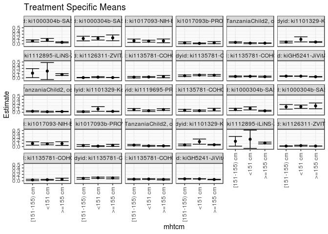

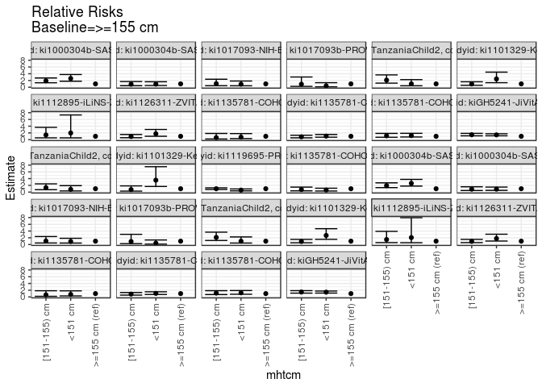

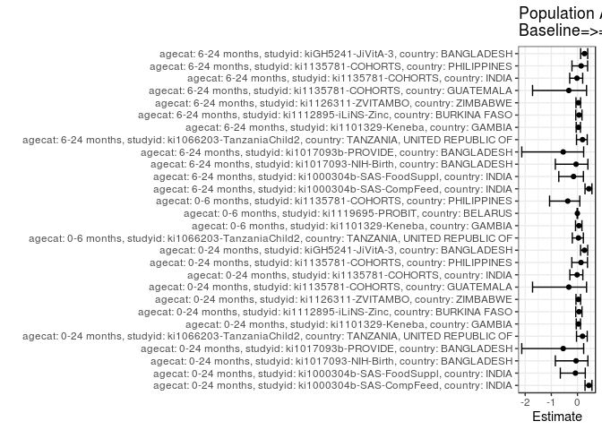

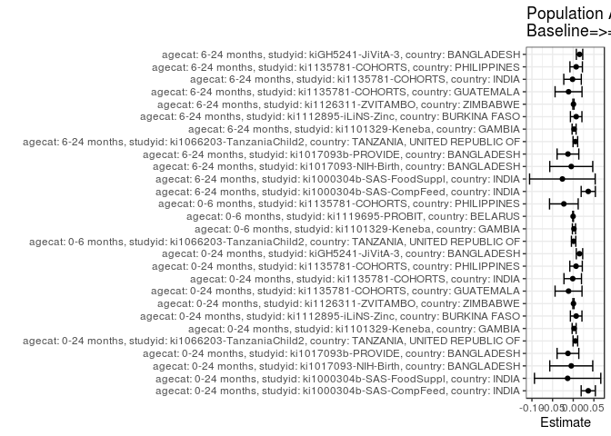

## Results Table

### Parameter: TSM

| agecat | studyid | country | intervention_level | baseline_level | estimate | ci_lower | ci_upper |
| --- | --- | --- | --- | --- | --- | --- | --- |
| 0-24 months | ki1000304b-SAS-CompFeed | INDIA | >=155 cm | NA | 0.0471123 | 0.0322679 | 0.0619567 |
| 0-24 months | ki1000304b-SAS-CompFeed | INDIA | <151 cm | NA | 0.1222257 | 0.0748636 | 0.1695877 |
| 0-24 months | ki1000304b-SAS-CompFeed | INDIA | [151-155) cm | NA | 0.0899304 | 0.0555640 | 0.1242968 |
| 0-24 months | ki1000304b-SAS-FoodSuppl | INDIA | >=155 cm | NA | 0.1868852 | 0.0965369 | 0.2772334 |
| 0-24 months | ki1000304b-SAS-FoodSuppl | INDIA | <151 cm | NA | 0.1711367 | 0.1179451 | 0.2243283 |
| 0-24 months | ki1000304b-SAS-FoodSuppl | INDIA | [151-155) cm | NA | 0.1645420 | 0.0931610 | 0.2359229 |
| 0-24 months | ki1017093-NIH-Birth | BANGLADESH | >=155 cm | NA | 0.0927835 | 0.0349925 | 0.1505745 |
| 0-24 months | ki1017093-NIH-Birth | BANGLADESH | <151 cm | NA | 0.0830671 | 0.0524639 | 0.1136702 |
| 0-24 months | ki1017093-NIH-Birth | BANGLADESH | [151-155) cm | NA | 0.0967742 | 0.0446880 | 0.1488603 |
| 0-24 months | ki1017093b-PROVIDE | BANGLADESH | >=155 cm | NA | 0.0362319 | 0.0050301 | 0.0674337 |
| 0-24 months | ki1017093b-PROVIDE | BANGLADESH | <151 cm | NA | 0.0143678 | 0.0018551 | 0.0268805 |
| 0-24 months | ki1017093b-PROVIDE | BANGLADESH | [151-155) cm | NA | 0.0324675 | 0.0044529 | 0.0604822 |
| 0-24 months | ki1066203-TanzaniaChild2 | TANZANIA, UNITED REPUBLIC OF | >=155 cm | NA | 0.0215613 | 0.0137972 | 0.0293255 |
| 0-24 months | ki1066203-TanzaniaChild2 | TANZANIA, UNITED REPUBLIC OF | <151 cm | NA | 0.0214724 | 0.0057337 | 0.0372111 |
| 0-24 months | ki1066203-TanzaniaChild2 | TANZANIA, UNITED REPUBLIC OF | [151-155) cm | NA | 0.0454545 | 0.0264562 | 0.0644529 |
| 0-24 months | ki1101329-Keneba | GAMBIA | >=155 cm | NA | 0.0567720 | 0.0460825 | 0.0674616 |
| 0-24 months | ki1101329-Keneba | GAMBIA | <151 cm | NA | 0.1394003 | 0.0597392 | 0.2190614 |
| 0-24 months | ki1101329-Keneba | GAMBIA | [151-155) cm | NA | 0.0551880 | 0.0291782 | 0.0811977 |
| 0-24 months | ki1112895-iLiNS-Zinc | BURKINA FASO | >=155 cm | NA | 0.1101923 | 0.0824904 | 0.1378941 |
| 0-24 months | ki1112895-iLiNS-Zinc | BURKINA FASO | <151 cm | NA | 0.2176597 | -0.0468427 | 0.4821622 |
| 0-24 months | ki1112895-iLiNS-Zinc | BURKINA FASO | [151-155) cm | NA | 0.1545383 | 0.0141817 | 0.2948948 |
| 0-24 months | ki1126311-ZVITAMBO | ZIMBABWE | >=155 cm | NA | 0.0165248 | 0.0134174 | 0.0196322 |
| 0-24 months | ki1126311-ZVITAMBO | ZIMBABWE | <151 cm | NA | 0.0288831 | 0.0139618 | 0.0438043 |
| 0-24 months | ki1126311-ZVITAMBO | ZIMBABWE | [151-155) cm | NA | 0.0156064 | 0.0085731 | 0.0226398 |
| 0-24 months | ki1135781-COHORTS | GUATEMALA | >=155 cm | NA | 0.0454545 | 0.0099029 | 0.0810062 |
| 0-24 months | ki1135781-COHORTS | GUATEMALA | <151 cm | NA | 0.0340237 | 0.0203508 | 0.0476966 |
| 0-24 months | ki1135781-COHORTS | GUATEMALA | [151-155) cm | NA | 0.0275229 | 0.0057950 | 0.0492509 |
| 0-24 months | ki1135781-COHORTS | INDIA | >=155 cm | NA | 0.0874269 | 0.0621713 | 0.1126826 |
| 0-24 months | ki1135781-COHORTS | INDIA | <151 cm | NA | 0.0928767 | 0.0716924 | 0.1140610 |
| 0-24 months | ki1135781-COHORTS | INDIA | [151-155) cm | NA | 0.0746350 | 0.0498767 | 0.0993932 |

[output cut: 54 more lines]

### Parameter: E(Y)

| agecat | studyid | country | intervention_level | baseline_level | estimate | ci_lower | ci_upper |
| --- | --- | --- | --- | --- | --- | --- | --- |
| 0-24 months | ki1000304b-SAS-CompFeed | INDIA | NA | NA | 0.0835322 | 0.0594080 | 0.1076564 |
| 0-24 months | ki1000304b-SAS-FoodSuppl | INDIA | NA | NA | 0.1733333 | 0.1349698 | 0.2116969 |
| 0-24 months | ki1017093-NIH-Birth | BANGLADESH | NA | NA | 0.0880150 | 0.0639627 | 0.1120673 |
| 0-24 months | ki1017093b-PROVIDE | BANGLADESH | NA | NA | 0.0234375 | 0.0117074 | 0.0351676 |
| 0-24 months | ki1066203-TanzaniaChild2 | TANZANIA, UNITED REPUBLIC OF | NA | NA | 0.0267229 | 0.0198773 | 0.0335686 |
| 0-24 months | ki1101329-Keneba | GAMBIA | NA | NA | 0.0589601 | 0.0490104 | 0.0689098 |
| 0-24 months | ki1112895-iLiNS-Zinc | BURKINA FASO | NA | NA | 0.1173252 | 0.0921861 | 0.1424644 |
| 0-24 months | ki1126311-ZVITAMBO | ZIMBABWE | NA | NA | 0.0171191 | 0.0143076 | 0.0199306 |
| 0-24 months | ki1135781-COHORTS | GUATEMALA | NA | NA | 0.0341131 | 0.0230006 | 0.0452255 |
| 0-24 months | ki1135781-COHORTS | INDIA | NA | NA | 0.0862385 | 0.0726276 | 0.0998495 |
| 0-24 months | ki1135781-COHORTS | PHILIPPINES | NA | NA | 0.0512273 | 0.0430760 | 0.0593786 |
| 0-24 months | kiGH5241-JiVitA-3 | BANGLADESH | NA | NA | 0.0567893 | 0.0526505 | 0.0609282 |
| 0-6 months | ki1066203-TanzaniaChild2 | TANZANIA, UNITED REPUBLIC OF | NA | NA | 0.0251355 | 0.0183227 | 0.0319484 |
| 0-6 months | ki1101329-Keneba | GAMBIA | NA | NA | 0.0313006 | 0.0233701 | 0.0392311 |
| 0-6 months | ki1119695-PROBIT | BELARUS | NA | NA | 0.0852001 | 0.0575403 | 0.1128599 |
| 0-6 months | ki1135781-COHORTS | PHILIPPINES | NA | NA | 0.0609613 | 0.0448957 | 0.0770269 |
| 6-24 months | ki1000304b-SAS-CompFeed | INDIA | NA | NA | 0.0835322 | 0.0594080 | 0.1076564 |
| 6-24 months | ki1000304b-SAS-FoodSuppl | INDIA | NA | NA | 0.1733333 | 0.1349698 | 0.2116969 |
| 6-24 months | ki1017093-NIH-Birth | BANGLADESH | NA | NA | 0.0880150 | 0.0639627 | 0.1120673 |
| 6-24 months | ki1017093b-PROVIDE | BANGLADESH | NA | NA | 0.0234375 | 0.0117074 | 0.0351676 |
| 6-24 months | ki1066203-TanzaniaChild2 | TANZANIA, UNITED REPUBLIC OF | NA | NA | 0.0267229 | 0.0198773 | 0.0335686 |
| 6-24 months | ki1101329-Keneba | GAMBIA | NA | NA | 0.0589601 | 0.0490104 | 0.0689098 |
| 6-24 months | ki1112895-iLiNS-Zinc | BURKINA FASO | NA | NA | 0.1173252 | 0.0921861 | 0.1424644 |
| 6-24 months | ki1126311-ZVITAMBO | ZIMBABWE | NA | NA | 0.0171191 | 0.0143076 | 0.0199306 |
| 6-24 months | ki1135781-COHORTS | GUATEMALA | NA | NA | 0.0341131 | 0.0230006 | 0.0452255 |
| 6-24 months | ki1135781-COHORTS | INDIA | NA | NA | 0.0862385 | 0.0726276 | 0.0998495 |
| 6-24 months | ki1135781-COHORTS | PHILIPPINES | NA | NA | 0.0512273 | 0.0430760 | 0.0593786 |
| 6-24 months | kiGH5241-JiVitA-3 | BANGLADESH | NA | NA | 0.0567893 | 0.0526505 | 0.0609282 |

### Parameter: RR

| agecat | studyid | country | intervention_level | baseline_level | estimate | ci_lower | ci_upper |
| --- | --- | --- | --- | --- | --- | --- | --- |
| 0-24 months | ki1000304b-SAS-CompFeed | INDIA | >=155 cm | >=155 cm | 1.0000000 | 1.0000000 | 1.0000000 |
| 0-24 months | ki1000304b-SAS-CompFeed | INDIA | <151 cm | >=155 cm | 2.5943485 | 1.7865213 | 3.7674580 |
| 0-24 months | ki1000304b-SAS-CompFeed | INDIA | [151-155) cm | >=155 cm | 1.9088525 | 1.3289744 | 2.7417517 |
| 0-24 months | ki1000304b-SAS-FoodSuppl | INDIA | >=155 cm | >=155 cm | 1.0000000 | 1.0000000 | 1.0000000 |
| 0-24 months | ki1000304b-SAS-FoodSuppl | INDIA | <151 cm | >=155 cm | 0.9157319 | 0.5163135 | 1.6241391 |
| 0-24 months | ki1000304b-SAS-FoodSuppl | INDIA | [151-155) cm | >=155 cm | 0.8804442 | 0.4606349 | 1.6828556 |
| 0-24 months | ki1017093-NIH-Birth | BANGLADESH | >=155 cm | >=155 cm | 1.0000000 | 1.0000000 | 1.0000000 |
| 0-24 months | ki1017093-NIH-Birth | BANGLADESH | <151 cm | >=155 cm | 0.8952787 | 0.4341874 | 1.8460323 |
| 0-24 months | ki1017093-NIH-Birth | BANGLADESH | [151-155) cm | >=155 cm | 1.0430108 | 0.4579132 | 2.3757155 |
| 0-24 months | ki1017093b-PROVIDE | BANGLADESH | >=155 cm | >=155 cm | 1.0000000 | 1.0000000 | 1.0000000 |
| 0-24 months | ki1017093b-PROVIDE | BANGLADESH | <151 cm | >=155 cm | 0.3965517 | 0.1165174 | 1.3496122 |
| 0-24 months | ki1017093b-PROVIDE | BANGLADESH | [151-155) cm | >=155 cm | 0.8961039 | 0.2648038 | 3.0324416 |
| 0-24 months | ki1066203-TanzaniaChild2 | TANZANIA, UNITED REPUBLIC OF | >=155 cm | >=155 cm | 1.0000000 | 1.0000000 | 1.0000000 |
| 0-24 months | ki1066203-TanzaniaChild2 | TANZANIA, UNITED REPUBLIC OF | <151 cm | >=155 cm | 0.9958748 | 0.4400867 | 2.2535709 |
| 0-24 months | ki1066203-TanzaniaChild2 | TANZANIA, UNITED REPUBLIC OF | [151-155) cm | >=155 cm | 2.1081505 | 1.2142426 | 3.6601405 |
| 0-24 months | ki1101329-Keneba | GAMBIA | >=155 cm | >=155 cm | 1.0000000 | 1.0000000 | 1.0000000 |
| 0-24 months | ki1101329-Keneba | GAMBIA | <151 cm | >=155 cm | 2.4554410 | 1.3451445 | 4.4821879 |
| 0-24 months | ki1101329-Keneba | GAMBIA | [151-155) cm | >=155 cm | 0.9720977 | 0.5852138 | 1.6147499 |
| 0-24 months | ki1112895-iLiNS-Zinc | BURKINA FASO | >=155 cm | >=155 cm | 1.0000000 | 1.0000000 | 1.0000000 |
| 0-24 months | ki1112895-iLiNS-Zinc | BURKINA FASO | <151 cm | >=155 cm | 1.9752726 | 0.5321733 | 7.3316374 |
| 0-24 months | ki1112895-iLiNS-Zinc | BURKINA FASO | [151-155) cm | >=155 cm | 1.4024420 | 0.5392450 | 3.6474026 |
| 0-24 months | ki1126311-ZVITAMBO | ZIMBABWE | >=155 cm | >=155 cm | 1.0000000 | 1.0000000 | 1.0000000 |
| 0-24 months | ki1126311-ZVITAMBO | ZIMBABWE | <151 cm | >=155 cm | 1.7478618 | 1.0086829 | 3.0287226 |
| 0-24 months | ki1126311-ZVITAMBO | ZIMBABWE | [151-155) cm | >=155 cm | 0.9444241 | 0.5795631 | 1.5389817 |
| 0-24 months | ki1135781-COHORTS | GUATEMALA | >=155 cm | >=155 cm | 1.0000000 | 1.0000000 | 1.0000000 |
| 0-24 months | ki1135781-COHORTS | GUATEMALA | <151 cm | >=155 cm | 0.7485207 | 0.3106798 | 1.8034108 |
| 0-24 months | ki1135781-COHORTS | GUATEMALA | [151-155) cm | >=155 cm | 0.6055046 | 0.1992921 | 1.8396905 |
| 0-24 months | ki1135781-COHORTS | INDIA | >=155 cm | >=155 cm | 1.0000000 | 1.0000000 | 1.0000000 |
| 0-24 months | ki1135781-COHORTS | INDIA | <151 cm | >=155 cm | 1.0623350 | 0.7351610 | 1.5351135 |
| 0-24 months | ki1135781-COHORTS | INDIA | [151-155) cm | >=155 cm | 0.8536841 | 0.5498333 | 1.3254500 |

[output cut: 54 more lines]

### Parameter: PAR

| agecat | studyid | country | intervention_level | baseline_level | estimate | ci_lower | ci_upper |
| --- | --- | --- | --- | --- | --- | --- | --- |
| 0-24 months | ki1000304b-SAS-CompFeed | INDIA | >=155 cm | NA | 0.0364199 | 0.0192127 | 0.0536272 |
| 0-24 months | ki1000304b-SAS-FoodSuppl | INDIA | >=155 cm | NA | -0.0135518 | -0.0938302 | 0.0667265 |
| 0-24 months | ki1017093-NIH-Birth | BANGLADESH | >=155 cm | NA | -0.0047685 | -0.0567779 | 0.0472409 |
| 0-24 months | ki1017093b-PROVIDE | BANGLADESH | >=155 cm | NA | -0.0127944 | -0.0390871 | 0.0134983 |
| 0-24 months | ki1066203-TanzaniaChild2 | TANZANIA, UNITED REPUBLIC OF | >=155 cm | NA | 0.0051616 | -0.0004171 | 0.0107402 |
| 0-24 months | ki1101329-Keneba | GAMBIA | >=155 cm | NA | 0.0021881 | -0.0026417 | 0.0070178 |
| 0-24 months | ki1112895-iLiNS-Zinc | BURKINA FASO | >=155 cm | NA | 0.0071330 | -0.0068491 | 0.0211151 |
| 0-24 months | ki1126311-ZVITAMBO | ZIMBABWE | >=155 cm | NA | 0.0005943 | -0.0009160 | 0.0021046 |
| 0-24 months | ki1135781-COHORTS | GUATEMALA | >=155 cm | NA | -0.0113415 | -0.0439327 | 0.0212497 |
| 0-24 months | ki1135781-COHORTS | INDIA | >=155 cm | NA | -0.0011884 | -0.0223623 | 0.0199855 |
| 0-24 months | ki1135781-COHORTS | PHILIPPINES | >=155 cm | NA | 0.0068480 | -0.0082488 | 0.0219448 |
| 0-24 months | kiGH5241-JiVitA-3 | BANGLADESH | >=155 cm | NA | 0.0151645 | 0.0074254 | 0.0229036 |
| 0-6 months | ki1066203-TanzaniaChild2 | TANZANIA, UNITED REPUBLIC OF | >=155 cm | NA | 0.0009168 | -0.0043601 | 0.0061936 |
| 0-6 months | ki1101329-Keneba | GAMBIA | >=155 cm | NA | 0.0017566 | -0.0020811 | 0.0055943 |
| 0-6 months | ki1119695-PROBIT | BELARUS | >=155 cm | NA | -0.0003428 | -0.0012293 | 0.0005436 |
| 0-6 months | ki1135781-COHORTS | PHILIPPINES | >=155 cm | NA | -0.0226863 | -0.0573599 | 0.0119872 |
| 6-24 months | ki1000304b-SAS-CompFeed | INDIA | >=155 cm | NA | 0.0364199 | 0.0192127 | 0.0536272 |
| 6-24 months | ki1000304b-SAS-FoodSuppl | INDIA | >=155 cm | NA | -0.0262154 | -0.1056603 | 0.0532296 |
| 6-24 months | ki1017093-NIH-Birth | BANGLADESH | >=155 cm | NA | -0.0047685 | -0.0567779 | 0.0472409 |
| 6-24 months | ki1017093b-PROVIDE | BANGLADESH | >=155 cm | NA | -0.0127944 | -0.0390871 | 0.0134983 |
| 6-24 months | ki1066203-TanzaniaChild2 | TANZANIA, UNITED REPUBLIC OF | >=155 cm | NA | 0.0051616 | -0.0004171 | 0.0107402 |
| 6-24 months | ki1101329-Keneba | GAMBIA | >=155 cm | NA | 0.0020788 | -0.0027540 | 0.0069116 |
| 6-24 months | ki1112895-iLiNS-Zinc | BURKINA FASO | >=155 cm | NA | 0.0071478 | -0.0067618 | 0.0210574 |
| 6-24 months | ki1126311-ZVITAMBO | ZIMBABWE | >=155 cm | NA | 0.0005884 | -0.0009223 | 0.0020990 |
| 6-24 months | ki1135781-COHORTS | GUATEMALA | >=155 cm | NA | -0.0113415 | -0.0439327 | 0.0212497 |
| 6-24 months | ki1135781-COHORTS | INDIA | >=155 cm | NA | -0.0016559 | -0.0228512 | 0.0195395 |
| 6-24 months | ki1135781-COHORTS | PHILIPPINES | >=155 cm | NA | 0.0071260 | -0.0079467 | 0.0221987 |
| 6-24 months | kiGH5241-JiVitA-3 | BANGLADESH | >=155 cm | NA | 0.0152601 | 0.0075373 | 0.0229829 |

### Parameter: PAF

| agecat | studyid | country | intervention_level | baseline_level | estimate | ci_lower | ci_upper |
| --- | --- | --- | --- | --- | --- | --- | --- |
| 0-24 months | ki1000304b-SAS-CompFeed | INDIA | >=155 cm | NA | 0.4359988 | 0.2883859 | 0.5529918 |
| 0-24 months | ki1000304b-SAS-FoodSuppl | INDIA | >=155 cm | NA | -0.0781837 | -0.6561495 | 0.2980827 |
| 0-24 months | ki1017093-NIH-Birth | BANGLADESH | >=155 cm | NA | -0.0541785 | -0.8462698 | 0.3980878 |
| 0-24 months | ki1017093b-PROVIDE | BANGLADESH | >=155 cm | NA | -0.5458937 | -2.1301295 | 0.2365212 |
| 0-24 months | ki1066203-TanzaniaChild2 | TANZANIA, UNITED REPUBLIC OF | >=155 cm | NA | 0.1931520 | -0.0377679 | 0.3726886 |
| 0-24 months | ki1101329-Keneba | GAMBIA | >=155 cm | NA | 0.0371108 | -0.0480790 | 0.1153762 |
| 0-24 months | ki1112895-iLiNS-Zinc | BURKINA FASO | >=155 cm | NA | 0.0607965 | -0.0658120 | 0.1723652 |
| 0-24 months | ki1126311-ZVITAMBO | ZIMBABWE | >=155 cm | NA | 0.0347160 | -0.0574765 | 0.1188711 |
| 0-24 months | ki1135781-COHORTS | GUATEMALA | >=155 cm | NA | -0.3324675 | -1.7178844 | 0.3467457 |
| 0-24 months | ki1135781-COHORTS | INDIA | >=155 cm | NA | -0.0137805 | -0.2915844 | 0.2042712 |
| 0-24 months | ki1135781-COHORTS | PHILIPPINES | >=155 cm | NA | 0.1336783 | -0.2163377 | 0.3829729 |
| 0-24 months | kiGH5241-JiVitA-3 | BANGLADESH | >=155 cm | NA | 0.2670308 | 0.1192801 | 0.3899946 |
| 0-6 months | ki1066203-TanzaniaChild2 | TANZANIA, UNITED REPUBLIC OF | >=155 cm | NA | 0.0364737 | -0.1978128 | 0.2249348 |
| 0-6 months | ki1101329-Keneba | GAMBIA | >=155 cm | NA | 0.0561203 | -0.0739221 | 0.1704158 |
| 0-6 months | ki1119695-PROBIT | BELARUS | >=155 cm | NA | -0.0040239 | -0.0144319 | 0.0062773 |
| 0-6 months | ki1135781-COHORTS | PHILIPPINES | >=155 cm | NA | -0.3721431 | -1.0668625 | 0.0890654 |
| 6-24 months | ki1000304b-SAS-CompFeed | INDIA | >=155 cm | NA | 0.4359988 | 0.2883859 | 0.5529918 |
| 6-24 months | ki1000304b-SAS-FoodSuppl | INDIA | >=155 cm | NA | -0.1512424 | -0.7145148 | 0.2269772 |
| 6-24 months | ki1017093-NIH-Birth | BANGLADESH | >=155 cm | NA | -0.0541785 | -0.8462698 | 0.3980878 |
| 6-24 months | ki1017093b-PROVIDE | BANGLADESH | >=155 cm | NA | -0.5458937 | -2.1301295 | 0.2365212 |
| 6-24 months | ki1066203-TanzaniaChild2 | TANZANIA, UNITED REPUBLIC OF | >=155 cm | NA | 0.1931520 | -0.0377679 | 0.3726886 |
| 6-24 months | ki1101329-Keneba | GAMBIA | >=155 cm | NA | 0.0352574 | -0.0499982 | 0.1135906 |
| 6-24 months | ki1112895-iLiNS-Zinc | BURKINA FASO | >=155 cm | NA | 0.0609231 | -0.0649521 | 0.1719202 |
| 6-24 months | ki1126311-ZVITAMBO | ZIMBABWE | >=155 cm | NA | 0.0343694 | -0.0578470 | 0.1185470 |
| 6-24 months | ki1135781-COHORTS | GUATEMALA | >=155 cm | NA | -0.3324675 | -1.7178844 | 0.3467457 |
| 6-24 months | ki1135781-COHORTS | INDIA | >=155 cm | NA | -0.0192012 | -0.2971377 | 0.1991821 |
| 6-24 months | ki1135781-COHORTS | PHILIPPINES | >=155 cm | NA | 0.1391047 | -0.2105959 | 0.3877885 |
| 6-24 months | kiGH5241-JiVitA-3 | BANGLADESH | >=155 cm | NA | 0.2687136 | 0.1213597 | 0.3913552 |